# Assignment 5: Space-Time Prediction of Bike Share Demand

#### Add Time Features

```r
study_panel <- study_panel %>%
  mutate(
    week = week(interval60),
    month = month(interval60, label = TRUE),
    dotw = wday(interval60, label = TRUE),
    hour = hour(interval60),
    date = as.Date(interval60),
    weekend = ifelse(dotw %in% c("Sat", "Sun"), 1, 0),
    rush_hour = ifelse(hour %in% c(7, 8, 9, 16, 17, 18), 1, 0)
  )
```

#### Join Weather Data

```r
study_panel <- study_panel %>%
  left_join(weather_complete, by = "interval60")

# Check for missing values
summary(study_panel %>% select(Trip_Count, Temperature, Precipitation))
```

```
   Trip_Count       Temperature   Precipitation
 Min.   : 0.0000   Min.   :12.0   Min.   :0.0000
 1st Qu.: 0.0000   1st Qu.:41.0   1st Qu.:0.0000
 Median : 0.0000   Median :51.0   Median :0.0000
 Mean   : 0.5178   Mean   :50.8   Mean   :0.0042
 3rd Qu.: 1.0000   3rd Qu.:61.0   3rd Qu.:0.0000
 Max.   :28.0000   Max.   :83.0   Max.   :0.5200
                   NA's   :5688   NA's   :5688
```

#### Create Temporal Lag Variables

```r
# Sort by station and time
study_panel <- study_panel %>%
  arrange(start_station, interval60)

# Create lag variables WITHIN each station
study_panel <- study_panel %>%
  group_by(start_station) %>%
  mutate(
    lag1Hour = lag(Trip_Count, 1),
    lag2Hours = lag(Trip_Count, 2),
    lag3Hours = lag(Trip_Count, 3),
    lag12Hours = lag(Trip_Count, 12),
    lag1day = lag(Trip_Count, 24)
  ) %>%
  ungroup()

# Remove rows with NA lags (first 24 hours for each station)
study_panel_complete <- study_panel %>%
  filter(!is.na(lag1day))

cat("Rows after removing NA lags:", format(nrow(study_panel_complete), big.mark = ","), "\n")
```

```
Rows after removing NA lags: 605,298
```

#### Visualize Lag Correlations

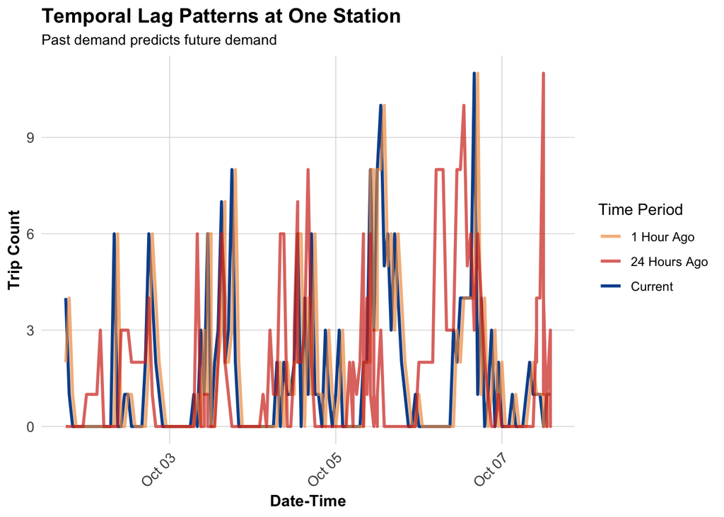

```r
# Sample one station to visualize
example_station <- study_panel_complete %>%
  filter(start_station == 3212) %>%
  head(168)  # One week

# Plot actual vs lagged demand
ggplot(example_station, aes(x = interval60)) +
  geom_line(aes(y = Trip_Count, color = "Current"), linewidth = 1) +
  geom_line(aes(y = lag1Hour, color = "1 Hour Ago"), linewidth = 1, alpha = 0.7) +
  geom_line(aes(y = lag1day, color = "24 Hours Ago"), linewidth = 1, alpha = 0.7) +
  scale_color_manual(values = c(
    "Current" = "#08519c",
    "1 Hour Ago" = "#F09B4E",
    "24 Hours Ago" = "#D3321D"
  )) +
  labs(
    title = "Temporal Lag Patterns at One Station",
    subtitle = "Past demand predicts future demand",
    x = "Date-Time",
    y = "Trip Count",
    color = "Time Period"
  ) +
  plotTheme
```

#### Temporal Train/Test Split

```r
# Split by week
# Q4 has weeks 40-53 (Oct-Dec)
# Train on weeks 40-49 (Oct 1 - early December)
# Test on weeks 50-53 (rest of December)

# Which stations have trips in BOTH early and late periods?
early_stations <- study_panel_complete %>%
  filter(week < 50) %>%
  filter(Trip_Count > 0) %>%
  distinct(start_station) %>%
  pull(start_station)

late_stations <- study_panel_complete %>%
  filter(week >= 50) %>%
  filter(Trip_Count > 0) %>%
  distinct(start_station) %>%
  pull(start_station)

# Keep only stations that appear in BOTH periods
common_stations <- intersect(early_stations, late_stations)

# Filter panel to only common stations
study_panel_complete <- study_panel_complete %>%
  filter(start_station %in% common_stations)

# NOW create train/test split
train <- study_panel_complete %>%
  filter(week < 50)

test <- study_panel_complete %>%
  filter(week >= 50)

cat("Training observations:", format(nrow(train), big.mark = ","), "\n")
```

```
Training observations: 410,628
```

```r
cat("Testing observations:", format(nrow(test), big.mark = ","), "\n")
```

```
Testing observations: 171,684
```

```r
cat("Training date range:", min(train$date), "to", max(train$date), "\n")
```

```
Training date range: 19997 to 20065
```

```r
cat("Testing date range:", min(test$date), "to", max(test$date), "\n")
```

```
Testing date range: 20066 to 20088
```

#### Model 1: Baseline (Time + Weather)

```r
# Create day of week factor with treatment (dummy) coding
train <- train %>%
  mutate(dotw_simple = factor(dotw, levels = c("Mon", "Tue", "Wed", "Thu", "Fri", "Sat", "Sun")))

# Set contrasts to treatment coding (dummy variables)
contrasts(train$dotw_simple) <- contr.treatment(7)

# Now run the model
model1 <- lm(
  Trip_Count ~ as.factor(hour) + dotw_simple + Temperature + Precipitation,
  data = train
)

summary(model1)
```

```
Call:
lm(formula = Trip_Count ~ as.factor(hour) + dotw_simple + Temperature +
    Precipitation, data = train)

Residuals:
    Min      1Q  Median      3Q     Max
-1.7089 -0.6783 -0.2159  0.1882 27.2727

Coefficients:
                   Estimate Std. Error t value             Pr(>|t|)
(Intercept)       -0.489156   0.013731 -35.624 < 0.0000000000000002 ***
as.factor(hour)1  -0.055267   0.012906  -4.282   0.0000184994686084 ***
as.factor(hour)2  -0.078435   0.012690  -6.181   0.0000000006378151 ***
as.factor(hour)3  -0.110234   0.012655  -8.711 < 0.0000000000000002 ***
as.factor(hour)4  -0.074204   0.012566  -5.905   0.0000000035263476 ***
as.factor(hour)5   0.038930   0.012623   3.084             0.002042 **
as.factor(hour)6   0.296063   0.012639  23.424 < 0.0000000000000002 ***
as.factor(hour)7   0.562184   0.012853  43.738 < 0.0000000000000002 ***
as.factor(hour)8   0.940524   0.012603  74.629 < 0.0000000000000002 ***
as.factor(hour)9   0.681527   0.012691  53.700 < 0.0000000000000002 ***
as.factor(hour)10  0.562441   0.012526  44.900 < 0.0000000000000002 ***
as.factor(hour)11  0.602993   0.012538  48.094 < 0.0000000000000002 ***
as.factor(hour)12  0.698148   0.012435  56.145 < 0.0000000000000002 ***
as.factor(hour)13  0.667308   0.012338  54.085 < 0.0000000000000002 ***
as.factor(hour)14  0.685610   0.012386  55.355 < 0.0000000000000002 ***
as.factor(hour)15  0.791576   0.012780  61.940 < 0.0000000000000002 ***
as.factor(hour)16  0.906925   0.012549  72.273 < 0.0000000000000002 ***
as.factor(hour)17  1.110205   0.012639  87.842 < 0.0000000000000002 ***
as.factor(hour)18  0.831297   0.012728  65.314 < 0.0000000000000002 ***
as.factor(hour)19  0.541516   0.012768  42.412 < 0.0000000000000002 ***
as.factor(hour)20  0.341348   0.012858  26.547 < 0.0000000000000002 ***
as.factor(hour)21  0.233603   0.012881  18.135 < 0.0000000000000002 ***
as.factor(hour)22  0.175194   0.012820  13.666 < 0.0000000000000002 ***
as.factor(hour)23  0.076033   0.012906   5.891   0.0000000038337890 ***
dotw_simple2       0.065588   0.006869   9.549 < 0.0000000000000002 ***
dotw_simple3       0.062920   0.006857   9.177 < 0.0000000000000002 ***
dotw_simple4      -0.050061   0.006571  -7.619   0.0000000000000257 ***
dotw_simple5      -0.012223   0.006833  -1.789             0.073612 .
dotw_simple6      -0.024444   0.006806  -3.591             0.000329 ***
dotw_simple7      -0.050983   0.006924  -7.363   0.0000000000001797 ***
Temperature        0.012467   0.000161  77.432 < 0.0000000000000002 ***
Precipitation     -1.109233   0.081793 -13.562 < 0.0000000000000002 ***
---
Signif. codes:  0 '***' 0.001 '**' 0.01 '*' 0.05 '.' 0.1 ' ' 1

Residual standard error: 1.144 on 410596 degrees of freedom
Multiple R-squared:  0.1141,    Adjusted R-squared:  0.114
F-statistic:  1705 on 31 and 410596 DF,  p-value: < 0.00000000000000022
```

**Patterns:**

- Tuesday and Wednesday have positive coefficients (0.066 and 0.063)
- Thursday through Sunday have negative coefficients
- Tuesday has the highest weekday effect (+0.066)
- This might be a reflection of concentrated commuting patterns at the beginning of the week, and towards the end of the work week there may be more flexible hyrib or work from jobs influencing fewer trips than a Monday.

**Hourly Patterns**

Hour Coefficient Interpretation 0 (baseline) 0.000 trips/hour (midnight) 1 -0.055 slightly fewer than midnight … 5 +0.039 morning activity starting … 8 +0.941 PEAK morning rush … 10 +0.562 post-rush … 17 +1.110 PEAK evening rush … 23 +0.076 late night minimal

#### Model 2: Add Temporal Lags

```r
model2 <- lm(
  Trip_Count ~ as.factor(hour) + dotw_simple + Temperature + Precipitation +
    lag1Hour + lag3Hours + lag1day,
  data = train
)

summary(model2)
```

```
Call:
lm(formula = Trip_Count ~ as.factor(hour) + dotw_simple + Temperature +
    Precipitation + lag1Hour + lag3Hours + lag1day, data = train)

Residuals:
     Min       1Q   Median       3Q      Max
-12.8428  -0.4697  -0.1265   0.1225  25.5313

Coefficients:
                    Estimate Std. Error t value             Pr(>|t|)
(Intercept)       -0.1971724  0.0120171 -16.408 < 0.0000000000000002 ***
as.factor(hour)1  -0.0175731  0.0112639  -1.560              0.11873
as.factor(hour)2  -0.0093400  0.0110785  -0.843              0.39918
as.factor(hour)3  -0.0323163  0.0110523  -2.924              0.00346 **
as.factor(hour)4  -0.0064036  0.0109793  -0.583              0.55973
as.factor(hour)5   0.0625618  0.0110386   5.668  0.00000001449553616 ***
as.factor(hour)6   0.2581886  0.0110639  23.336 < 0.0000000000000002 ***
as.factor(hour)7   0.4087297  0.0112659  36.280 < 0.0000000000000002 ***
as.factor(hour)8   0.6475387  0.0110725  58.482 < 0.0000000000000002 ***
as.factor(hour)9   0.2687374  0.0111533  24.095 < 0.0000000000000002 ***
as.factor(hour)10  0.2122365  0.0109778  19.333 < 0.0000000000000002 ***
as.factor(hour)11  0.2554385  0.0109944  23.234 < 0.0000000000000002 ***
as.factor(hour)12  0.3583675  0.0108988  32.881 < 0.0000000000000002 ***
as.factor(hour)13  0.3239304  0.0108163  29.948 < 0.0000000000000002 ***
as.factor(hour)14  0.3531805  0.0108536  32.540 < 0.0000000000000002 ***
as.factor(hour)15  0.4322898  0.0112024  38.589 < 0.0000000000000002 ***
as.factor(hour)16  0.5127136  0.0110123  46.558 < 0.0000000000000002 ***
as.factor(hour)17  0.6404994  0.0111130  57.635 < 0.0000000000000002 ***
as.factor(hour)18  0.3266069  0.0112005  29.160 < 0.0000000000000002 ***
as.factor(hour)19  0.1612724  0.0111995  14.400 < 0.0000000000000002 ***
as.factor(hour)20  0.0449273  0.0112804   3.983  0.00006812693842296 ***
as.factor(hour)21  0.0488508  0.0112677   4.335  0.00001454699054146 ***
as.factor(hour)22  0.0606778  0.0111954   5.420  0.00000005967221309 ***
as.factor(hour)23  0.0183651  0.0112646   1.630              0.10303
dotw_simple2       0.0070021  0.0059975   1.167              0.24301
dotw_simple3      -0.0128484  0.0059925  -2.144              0.03203 *
dotw_simple4      -0.0448243  0.0057357  -7.815  0.00000000000000551 ***
dotw_simple5      -0.0422563  0.0059684  -7.080  0.00000000000144379 ***
dotw_simple6      -0.0367596  0.0059417  -6.187  0.00000000061504630 ***
dotw_simple7      -0.0593011  0.0060464  -9.808 < 0.0000000000000002 ***
Temperature        0.0040641  0.0001426  28.494 < 0.0000000000000002 ***
Precipitation     -0.9676346  0.0714492 -13.543 < 0.0000000000000002 ***
lag1Hour           0.3238000  0.0014825 218.412 < 0.0000000000000002 ***
lag3Hours          0.1180469  0.0014504  81.387 < 0.0000000000000002 ***
lag1day            0.2027487  0.0013895 145.912 < 0.0000000000000002 ***
---
Signif. codes:  0 '***' 0.001 '**' 0.01 '*' 0.05 '.' 0.1 ' ' 1

Residual standard error: 0.9988 on 410593 degrees of freedom
Multiple R-squared:  0.3252,    Adjusted R-squared:  0.3252
F-statistic:  5821 on 34 and 410593 DF,  p-value: < 0.00000000000000022
```

**Adding lags improve R² by about 20 percentage points.** This is likely because the state of the Indego station an hour or a few hours before affects how many trips can be taken hours later, and the one day lag likely accounts for the peaks and ebs at the same time a day before, so it makes sense that this model can account for more of the variance in the data.

#### Model 3: Add Demographics

```r
model3 <- lm(
  Trip_Count ~ as.factor(hour) + dotw_simple + Temperature + Precipitation +
    lag1Hour + lag3Hours + lag1day +
    Med_Inc.x + Percent_Taking_Transit.y + Percent_White.y,
  data = train
)

summary(model3)
```

```
Call:
lm(formula = Trip_Count ~ as.factor(hour) + dotw_simple + Temperature +
    Precipitation + lag1Hour + lag3Hours + lag1day + Med_Inc.x +
    Percent_Taking_Transit.y + Percent_White.y, data = train)

Residuals:
     Min       1Q   Median       3Q      Max
-10.2603  -0.7198  -0.2719   0.4456  24.6278

Coefficients:
                              Estimate    Std. Error t value
(Intercept)               0.7009115282  0.0386608126  18.130
as.factor(hour)1         -0.0339064631  0.0443755122  -0.764
as.factor(hour)2         -0.0733390073  0.0472207425  -1.553
as.factor(hour)3         -0.1736198797  0.0563179188  -3.083
as.factor(hour)4         -0.1602016516  0.0526556216  -3.042
as.factor(hour)5         -0.0842198175  0.0392042217  -2.148
as.factor(hour)6          0.1812725910  0.0339389718   5.341
as.factor(hour)7          0.3659932453  0.0327798040  11.165
as.factor(hour)8          0.6419351722  0.0315874296  20.322
as.factor(hour)9          0.0689540443  0.0318174207   2.167
as.factor(hour)10         0.0455849373  0.0318601406   1.431
as.factor(hour)11         0.0951277607  0.0317831322   2.993
as.factor(hour)12         0.1718233329  0.0312986651   5.490
as.factor(hour)13         0.1501299648  0.0313008986   4.796
as.factor(hour)14         0.1546199385  0.0311814820   4.959
as.factor(hour)15         0.2738677333  0.0314129060   8.718
as.factor(hour)16         0.3825663042  0.0310863390  12.307
as.factor(hour)17         0.5958195674  0.0311303049  19.140
as.factor(hour)18         0.1871034280  0.0314626011   5.947
as.factor(hour)19         0.0105635560  0.0320040115   0.330
as.factor(hour)20        -0.0963042374  0.0327876103  -2.937
as.factor(hour)21        -0.0718694380  0.0336061149  -2.139
as.factor(hour)22        -0.0356940800  0.0343008260  -1.041
as.factor(hour)23        -0.0793554621  0.0360569574  -2.201
dotw_simple2              0.0015399442  0.0129720488   0.119
dotw_simple3             -0.0058302798  0.0131356919  -0.444
dotw_simple4             -0.0584003672  0.0128820191  -4.533
dotw_simple5             -0.0902616975  0.0132777688  -6.798
dotw_simple6             -0.0296928615  0.0133240066  -2.229
```

[output cut: 40 more lines]

```
Temperature              < 0.0000000000000002 ***
Precipitation            < 0.0000000000000002 ***
lag1Hour                 < 0.0000000000000002 ***
lag3Hours                < 0.0000000000000002 ***
lag1day                  < 0.0000000000000002 ***
Med_Inc.x                             0.12579
Percent_Taking_Transit.y < 0.0000000000000002 ***
Percent_White.y          < 0.0000000000000002 ***
---
Signif. codes:  0 '***' 0.001 '**' 0.01 '*' 0.05 '.' 0.1 ' ' 1

Residual standard error: 1.274 on 133822 degrees of freedom
  (276768 observations deleted due to missingness)
Multiple R-squared:  0.2192,    Adjusted R-squared:  0.219
F-statistic:  1015 on 37 and 133822 DF,  p-value: < 0.00000000000000022
```

#### Model 4: Add Station Fixed Effects

```r
model4 <- lm(
  Trip_Count ~ as.factor(hour) + dotw_simple + Temperature + Precipitation +
    lag1Hour + lag3Hours + lag1day +
    Med_Inc.x + Percent_Taking_Transit.y + Percent_White.y +
    as.factor(start_station),
  data = train
)

# Summary too long with all station dummies, just show key metrics
cat("Model 4 R-squared:", summary(model4)$r.squared, "\n")
```

```
Model 4 R-squared: 0.2469249
```

```r
cat("Model 4 Adj R-squared:", summary(model4)$adj.r.squared, "\n")
```

```
Model 4 Adj R-squared: 0.2454536
```

#### Model 5: Add Rush Hour Interaction

```r
model5 <- lm(
  Trip_Count ~ as.factor(hour) + dotw_simple + Temperature + Precipitation +
    lag1Hour + lag3Hours + lag1day + rush_hour + as.factor(month) +
    Med_Inc.x + Percent_Taking_Transit.y + Percent_White.y +
    as.factor(start_station) +
    rush_hour * weekend,  # Rush hour effects different on weekends
  data = train
)

cat("Model 5 R-squared:", summary(model5)$r.squared, "\n")
```

```
Model 5 R-squared: 0.2526638
```

```r
cat("Model 5 Adj R-squared:", summary(model5)$adj.r.squared, "\n")
```

```
Model 5 Adj R-squared: 0.251187
```

#### Model Evaluation: Calculate Predictions and MAE

```r
# Get predictions on test set

# Create day of week factor with treatment (dummy) coding
test <- test %>%
  mutate(dotw_simple = factor(dotw, levels = c("Mon", "Tue", "Wed", "Thu", "Fri", "Sat", "Sun")))

# Set contrasts to treatment coding (dummy variables)
contrasts(test$dotw_simple) <- contr.treatment(7)

test <- test %>%
  mutate(
    pred1 = predict(model1, newdata = test),
    pred2 = predict(model2, newdata = test),
    pred3 = predict(model3, newdata = test),
    pred4 = predict(model4, newdata = test),
    pred5 = predict(model5, newdata = test)
  )

# Calculate MAE for each model
mae_results <- data.frame(
  Model = c(
    "1. Time + Weather",
    "2. + Temporal Lags",
    "3. + Demographics",
    "4. + Station FE",
    "5. + Rush Hour Interaction"
  ),
  MAE = c(
    mean(abs(test$Trip_Count - test$pred1), na.rm = TRUE),
    mean(abs(test$Trip_Count - test$pred2), na.rm = TRUE),
    mean(abs(test$Trip_Count - test$pred3), na.rm = TRUE),
    mean(abs(test$Trip_Count - test$pred4), na.rm = TRUE),
    mean(abs(test$Trip_Count - test$pred5), na.rm = TRUE)
  )
)

kable(mae_results,
      digits = 2,
      caption = "Mean Absolute Error by Model (Test Set)",
      col.names = c("Model", "MAE (trips)")) %>%
  kable_styling(bootstrap_options = c("striped", "hover"))
```

Mean Absolute Error by Model (Test Set)

| Model | MAE (trips) |
| --- | --- |
| 1. Time + Weather | 0.54 |
| 2. + Temporal Lags | 0.40 |
| 3. + Demographics | 0.64 |
| 4. + Station FE | 0.66 |
| 5. + Rush Hour Interaction | 0.65 |

**Temporal Lags improved the model the most;** the biggest drop in mean absolute error was from the model accounting for time of day, day of week, and weather, and then adding in the temporal lags. In fact, adding demographics made the model perform worse than the baseline model, as well as adding station fixed effects and interaction effects on top of that.

**Compared to Q1 2025:**

The MAE values for Q4 2024 are fairly similar across the models. I believe this might be because both quarters account for season changes into winter (Q4) and out of winter (Q1) that make it harder to predict bike share in the latter part of the quarter based on the first, even when taking into account weather effects. There are also a high concentration of winter holidays that likely affect bike travel in Q4, such as Thanksgiving and Winter Break holidays, and in Q1 New Years, Valentine’s Day, and Spring Break holidays.

## Part 2: Error Analysis

#### Observed vs. Predicted Error Analysis

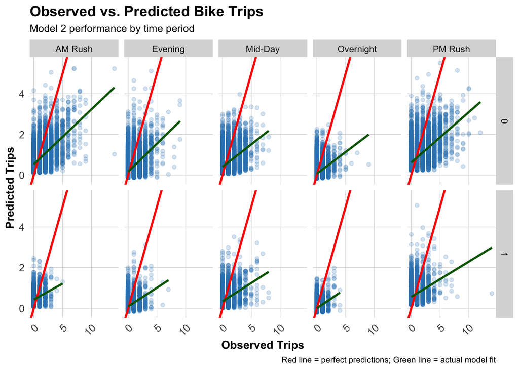

```r
test <- test %>%
  mutate(
    error = Trip_Count - pred2,
    abs_error = abs(error),
    time_of_day = case_when(
      hour < 7 ~ "Overnight",
      hour >= 7 & hour < 10 ~ "AM Rush",
      hour >= 10 & hour < 15 ~ "Mid-Day",
      hour >= 15 & hour <= 18 ~ "PM Rush",
      hour > 18 ~ "Evening"
    )
  )

# Scatter plot by time and day type
ggplot(test, aes(x = Trip_Count, y = pred2)) +
  geom_point(alpha = 0.2, color = "#3182bd") +
  geom_abline(slope = 1, intercept = 0, color = "red", linewidth = 1) +
  geom_smooth(method = "lm", se = FALSE, color = "darkgreen") +
  facet_grid(weekend ~ time_of_day) +
  labs(
    title = "Observed vs. Predicted Bike Trips",
    subtitle = "Model 2 performance by time period",
    x = "Observed Trips",
    y = "Predicted Trips",
    caption = "Red line = perfect predictions; Green line = actual model fit"
  ) +
  plotTheme
```

**The model consistently under predicts trips on weekdays, weekends, at all time periods of the day.** The one period that appears to be moderately better predicted is the AM Rush period of weekdays, and generally slightly better at predicting weekdays than weekends. However, the consistent under-predicting seems to signify there is a major driver of Indego trips that this model does not account for well.

#### Spatial Error Patterns

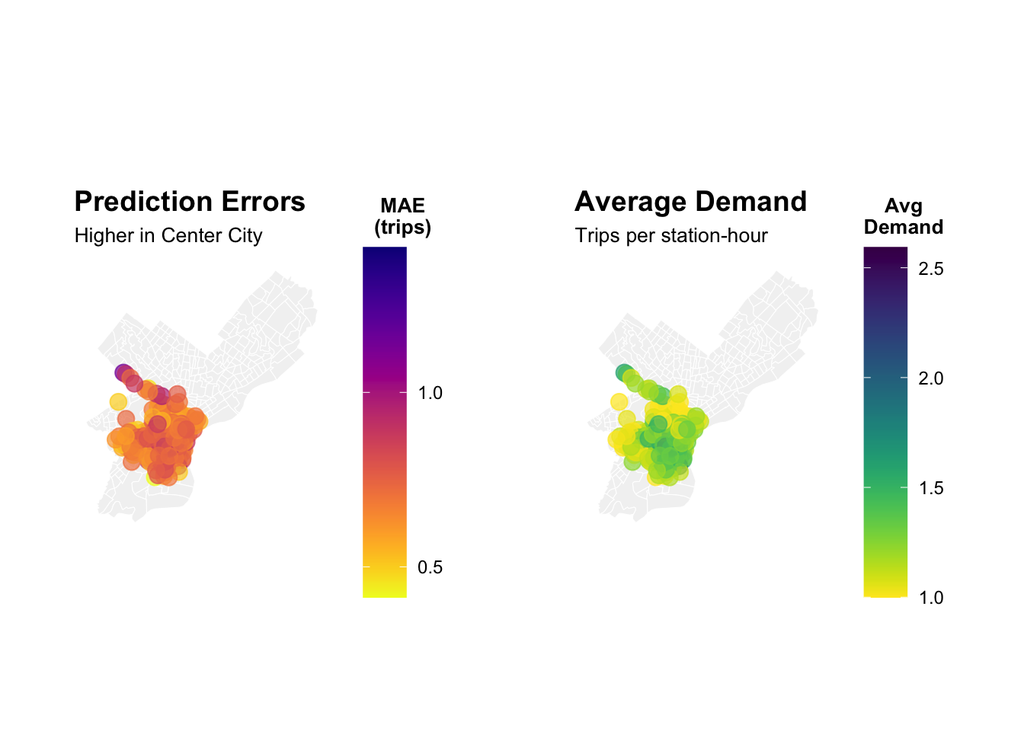

```r
# Calculate MAE by station
station_errors <- test %>%
  group_by(start_station, start_lat.x, start_lon.y) %>%
  summarize(
    MAE = mean(abs_error, na.rm = TRUE),
    avg_demand = mean(Trip_Count, na.rm = TRUE),
    .groups = "drop"
  ) %>%
  filter(!is.na(start_lat.x), !is.na(start_lon.y))

## Create Two Maps Side-by-Side with Proper Legends (sorry these maps are ugly)

# Calculate station errors
station_errors <- test %>%
  filter(!is.na(pred2)) %>%
  group_by(start_station, start_lat.x, start_lon.y) %>%
  summarize(
    MAE = mean(abs(Trip_Count - pred2), na.rm = TRUE),
    avg_demand = mean(Trip_Count, na.rm = TRUE),
    .groups = "drop"
  ) %>%
  filter(!is.na(start_lat.x), !is.na(start_lon.y))

# Map 1: Prediction Errors
p1 <- ggplot() +
  geom_sf(data = philly_census, fill = "grey95", color = "white", size = 0.2) +
  geom_point(
    data = station_errors,
    aes(x = start_lon.y, y = start_lat.x, color = MAE),
    size = 3.5,
    alpha = 0.7
  ) +
  scale_color_viridis(
    option = "plasma",
    name = "MAE\n(trips)",
    direction = -1,
    breaks = c(0.5, 1.0, 1.5),  # Fewer, cleaner breaks
    labels = c("0.5", "1.0", "1.5")
  ) +
  labs(title = "Prediction Errors",
       subtitle = "Higher in Center City") +
  mapTheme +
  theme(
    legend.position = "right",
    legend.title = element_text(size = 10, face = "bold"),
    legend.text = element_text(size = 9),
    plot.title = element_text(size = 14, face = "bold"),
    plot.subtitle = element_text(size = 10)
  ) +
  guides(color = guide_colorbar(
    barwidth = 1.5,
    barheight = 12,
    title.position = "top",
    title.hjust = 0.5
  ))

# Map 2: Average Demand
p2 <- ggplot() +
  geom_sf(data = philly_census, fill = "grey95", color = "white", size = 0.2) +
  geom_point(
    data = station_errors,
    aes(x = start_lon.y, y = start_lat.x, color = avg_demand),
    size = 3.5,
    alpha = 0.7
  ) +
  scale_color_viridis(
    option = "viridis",
    name = "Avg\nDemand",
    direction = -1,
    breaks = c(0.5, 1.0, 1.5, 2.0, 2.5),  # Clear breaks
    labels = c("0.5", "1.0", "1.5", "2.0", "2.5")
  ) +
  labs(title = "Average Demand",
       subtitle = "Trips per station-hour") +
  mapTheme +
  theme(
    legend.position = "right",
    legend.title = element_text(size = 10, face = "bold"),
    legend.text = element_text(size = 9),
    plot.title = element_text(size = 14, face = "bold"),
    plot.subtitle = element_text(size = 10)
  ) +
  guides(color = guide_colorbar(
    barwidth = 1.5,
    barheight = 12,
    title.position = "top",
    title.hjust = 0.5
  ))

p1 | p2
```

#### Temporal Error Patterns

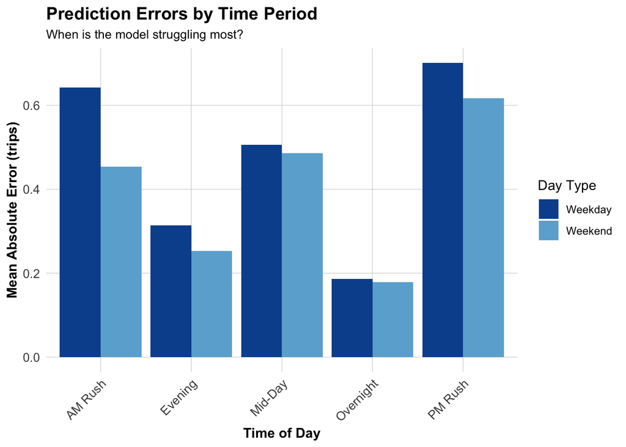

```r
# MAE by time of day and day type
temporal_errors <- test %>%
  group_by(time_of_day, weekend) %>%
  summarize(
    MAE = mean(abs_error, na.rm = TRUE),
    .groups = "drop"
  ) %>%
  mutate(day_type = ifelse(weekend == 1, "Weekend", "Weekday"))

ggplot(temporal_errors, aes(x = time_of_day, y = MAE, fill = day_type)) +
  geom_col(position = "dodge") +
  scale_fill_manual(values = c("Weekday" = "#08519c", "Weekend" = "#6baed6")) +
  labs(
    title = "Prediction Errors by Time Period",
    subtitle = "When is the model struggling most?",
    x = "Time of Day",
    y = "Mean Absolute Error (trips)",
    fill = "Day Type"
  ) +
  plotTheme +
  theme(axis.text.x = element_text(angle = 45, hjust = 1))
```

**MAEs are higher for weekdays than weekends on average,** but combined with the previous plots of observed vs predicted values, this shows that the mean absolute errors partially higher for weekdays because of higher trip counts on weekdays typically than weekends, and higher trip counts during that AM and PM rush. In other words, this again confirms that the model is creating predictions that are too uniform accross time and space.

#### Errors and Demographics

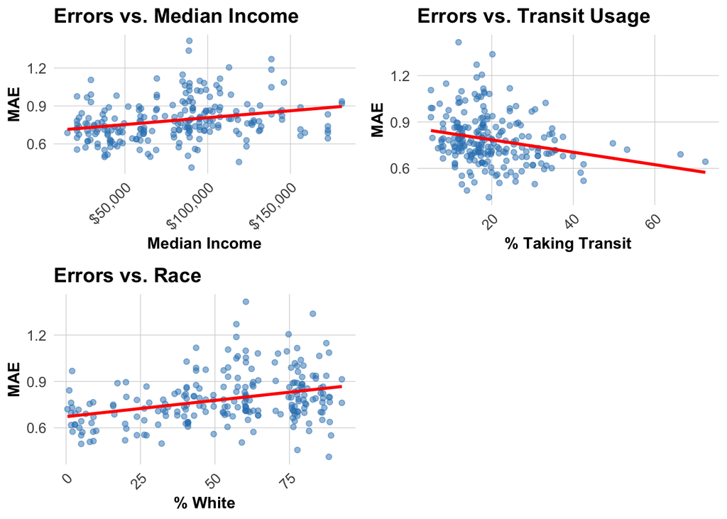

```r
# Join demographic data to station errors
station_errors_demo <- station_errors %>%
  left_join(
    station_attributes %>% select(start_station, Med_Inc, Percent_Taking_Transit, Percent_White),
    by = "start_station"
  ) %>%
  filter(!is.na(Med_Inc))

# Create plots
inc_plot <- ggplot(station_errors_demo, aes(x = Med_Inc, y = MAE)) +
  geom_point(alpha = 0.5, color = "#3182bd") +
  geom_smooth(method = "lm", se = FALSE, color = "red") +
  scale_x_continuous(labels = scales::dollar) +
  labs(title = "Errors vs. Median Income", x = "Median Income", y = "MAE") +
  plotTheme

transit_plot <- ggplot(station_errors_demo, aes(x = Percent_Taking_Transit, y = MAE)) +
  geom_point(alpha = 0.5, color = "#3182bd") +
  geom_smooth(method = "lm", se = FALSE, color = "red") +
  labs(title = "Errors vs. Transit Usage", x = "% Taking Transit", y = "MAE") +
  plotTheme

white_plot <- ggplot(station_errors_demo, aes(x = Percent_White, y = MAE)) +
  geom_point(alpha = 0.5, color = "#3182bd") +
  geom_smooth(method = "lm", se = FALSE, color = "red") +
  labs(title = "Errors vs. Race", x = "% White", y = "MAE") +
  plotTheme

grid.arrange(inc_plot, transit_plot, white_plot, ncol = 2)
```

**Prediction errors are higher for higher income and more White areas, but lower for higher transit-taking areas.** This again tracks with the general under-performance of the model, as percent White and median income are slightly positively correlated with trips and percent using transit is slightly negatively correlated with trips.

## Part 3: Feature Engineering & model improvement

After observing the error results from the first five models, I believe the biggest aspects the models are missing are spatial variables that influence bike share usage. Seeing as the under-counting is clustered around center city, I think some likely attributes of center city that make biking more attractive is the relative nearness of start and end destinations to each other (~80% of trips are under 1.5 miles). In other words, I think the model would be a better predictor if it took into account the potential rider’s available close-by destination bike stations they could park the bike within the average trip length that riders take. Additionally, I think people are more likely to feel comfortable biking when there are bikes lanes nearby or roads with a low posted speed limit. I also want to build off the success of adding the spatial lags that improved model 1 to model 2 so much, and add another lag for the same hour in the previous week.

```r
# Step 1: Build LINESTRING geometry for each row
trips_sf <- indego %>%
  filter(
    !is.na(start_lat),
    !is.na(start_lon),
    !is.na(end_lat),
    !is.na(end_lon)
  )%>%
  rowwise() %>%
  mutate(
    geometry = list(
      st_linestring(
        matrix(
          c(start_lon, start_lat,
            end_lon,   end_lat),
          ncol = 2,
          byrow = TRUE
        )
      )
    )
  ) %>%
  ungroup() %>%
  st_as_sf(crs = 4326)


# Step 2: Transform to PA South (meters)
trips_sf <- st_transform(trips_sf, 6539)


# Step 3: Calculate trip distance (meters)
trips_sf <- trips_sf %>%
  mutate(distance_f = st_length(geometry))

trips_sf <- trips_sf %>%
  mutate(
    distance_mi = as.numeric(distance_f) / 5280  # 1 mile = 5280 ft
  )

summary(trips_sf$distance_mi)
```

```
   Min. 1st Qu.  Median    Mean 3rd Qu.    Max.
 0.0000  0.5484  0.9063  1.0439  1.3783  8.8305
```

**Spatial features:**

- Number of low-speed roads near station
- Number and type of Bike lanes near station
- Nearness of station to other stations

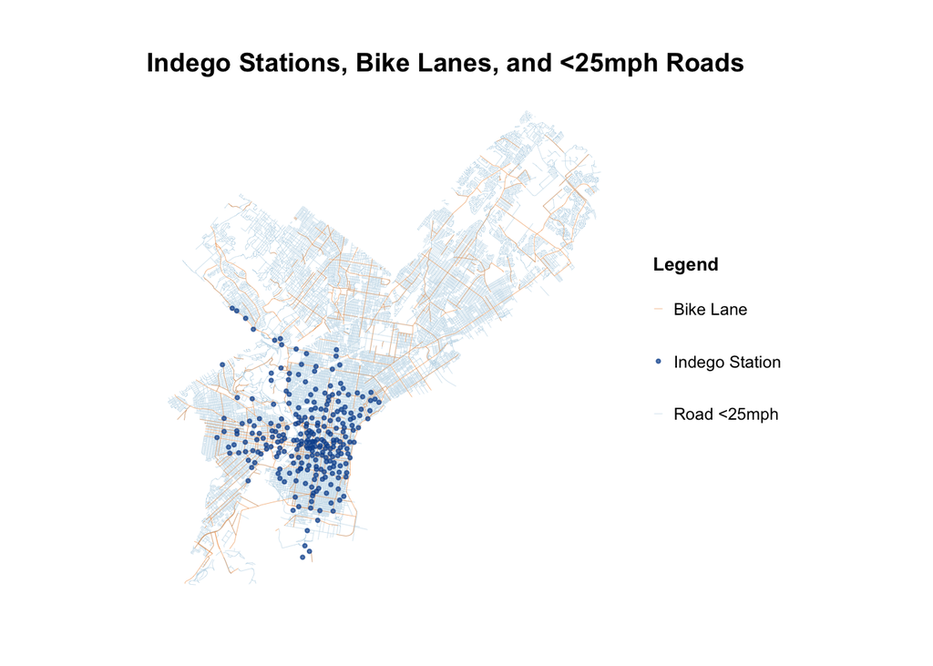

```r
roads_sf <- st_read("../data/RMSADMIN_(Administrative_Classifications_of_Roadway)/RMSADMIN_(Administrative_Classifications_of_Roadway).shp")
blanes_sf <- st_read("../data/Bike_Network/Bike_Network.shp")
# filter to just roadways in Phildelphia County under 25 mph
# Phildelphia CTY CODE is 67
roads_sf<-roads_sf%>%filter(
  CTY_CODE == 67,
  SPEED_LIMI<=25
)

roads_sf<-roads_sf%>%
  st_transform(st_crs(stations_sf))%>%
  mutate(label="Road <25mph")

blanes_sf<-blanes_sf%>%
  st_transform(st_crs(stations_sf))%>%
  mutate(label="Bike Lane")

stations_sf<-stations_sf%>%mutate(
  label="Indego Station"
)

# map with stations
ggplot() +
  geom_sf(data = roads_sf, aes(color = label), linewidth = 0.1) +
  geom_sf(data = blanes_sf, aes(color = label), linewidth = 0.1) +
  geom_sf(data = stations_sf, aes(color = label), size = 0.7, alpha = 0.7) +
  scale_color_manual(
    name = "Legend",
    values = c(
      "Road <25mph" = "#bdd7e7",
      "Bike Lane" = "#F09B4E",
      "Indego Station" = "#08519c"
    )
  ) +
  labs(title = "Indego Stations, Bike Lanes, and <25mph Roads") +
  mapTheme +
  theme(
    legend.position = "right",
    legend.title = element_text(size = 10, face = "bold"),
    legend.text = element_text(size = 9)
  )
```

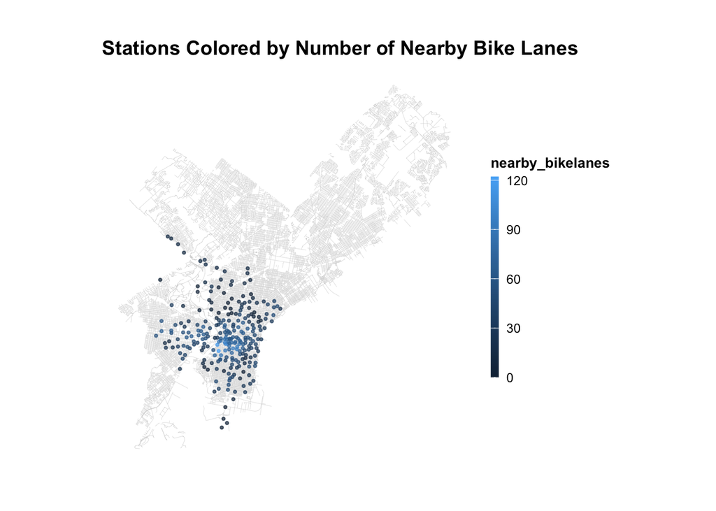

```r
stations_buffered <- stations_sf %>%
  mutate(buffer_geom = st_buffer(geometry, dist = 500))

# ---- Count roads intersecting each buffer ----
road_counts <- st_intersects(stations_buffered$buffer_geom, roads_sf) %>%
  lengths()

# ---- Count bike lanes intersecting each buffer ----
blane_counts <- st_intersects(stations_buffered$buffer_geom, blanes_sf) %>%
  lengths()

# ---- Add results back onto stations_sf ----
stations_sf <- stations_sf %>%
  mutate(
    nearby_roads  = road_counts,
    nearby_bikelanes = blane_counts
  )

ggplot() +
  geom_sf(data = roads_sf, color="lightgray", linewidth = 0.1) +
  geom_sf(data = stations_sf, aes(color = nearby_bikelanes), size = 0.7, alpha = 0.7) +
  labs(title = "Stations Colored by Number of Nearby Bike Lanes") +
  mapTheme +
  theme(
    legend.position = "right",
    legend.title = element_text(size = 10, face = "bold"),
    legend.text = element_text(size = 9)
  )
```

In addition to nearby bike lanes and slow roads, I will add the number of other bike stations within a buffer of the median trip distance of 0.9063 miles.

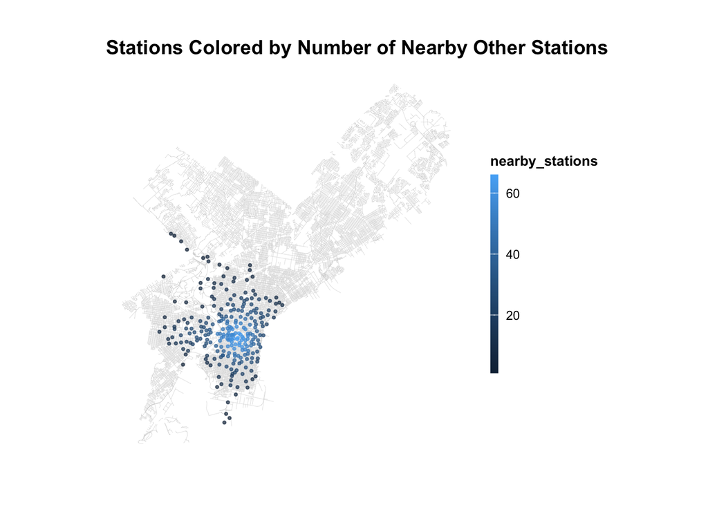

```r
# 0.9063 miles = 1458.54847 meters

stations_buffered <- stations_sf %>%
  mutate(buffer_geom = st_buffer(geometry, dist = 1458.54847))

# ---- Count indego stations intersecting each buffer ----
station_counts <- st_intersects(stations_buffered$buffer_geom, stations_sf) %>%
  lengths()

# ---- Add results back onto stations_sf ----
stations_sf <- stations_sf %>%
  mutate(
    nearby_stations  = station_counts
  )

ggplot() +
  geom_sf(data = roads_sf, color="lightgray", linewidth = 0.1) +
  geom_sf(data = stations_sf, aes(color = nearby_stations), size = 0.7, alpha = 0.7) +
  labs(title = "Stations Colored by Number of Nearby Other Stations") +
  mapTheme +
  theme(
    legend.position = "right",
    legend.title = element_text(size = 10, face = "bold"),
    legend.text = element_text(size = 9)
  )
```

```r
# Add back to trip data
study_panel <- study_panel %>%
  left_join(
    stations_sf %>%
      select(start_station, nearby_roads, nearby_bikelanes, nearby_stations),
    by = "start_station"
  )
```

**Trip history features:**

- Add lag for same hour last week

```r
study_panel <- study_panel %>%
  group_by(start_station) %>%
  mutate(
    lag1week = lag(Trip_Count, 168)
  ) %>%
  ungroup()

# Remove rows with NA lags (first 24 hours for each station)
study_panel_complete <- study_panel %>%
  filter(!is.na(lag1week) & !is.na(lag1day))

cat("Rows after removing NA lags:", format(nrow(study_panel_complete), big.mark = ","), "\n")
```

```
Rows after removing NA lags: 571,170
```

#### Model 6: Add nearby spatial features and 1-week lag

```r
study_panel_complete <- study_panel_complete %>%
  filter(start_station %in% common_stations)

# NOW create train/test split
train <- study_panel_complete %>%
  filter(week < 50)

test <- study_panel_complete %>%
  filter(week >= 50)

train <- train %>%
  mutate(dotw_simple = factor(dotw, levels = c("Mon", "Tue", "Wed", "Thu", "Fri", "Sat", "Sun")))

# Set contrasts to treatment coding (dummy variables)
contrasts(train$dotw_simple) <- contr.treatment(7)

test <- test %>%
  mutate(dotw_simple = factor(dotw, levels = c("Mon", "Tue", "Wed", "Thu", "Fri", "Sat", "Sun")))

# Set contrasts to treatment coding (dummy variables)
contrasts(test$dotw_simple) <- contr.treatment(7)

cat("Training observations:", format(nrow(train), big.mark = ","), "\n")
```

```
Training observations: 377,796
```

```r
cat("Testing observations:", format(nrow(test), big.mark = ","), "\n")
```

```
Testing observations: 171,684
```

```r
cat("Training date range:", min(train$date), "to", max(train$date), "\n")
```

```
Training date range: 20003 to 20065
```

```r
cat("Testing date range:", min(test$date), "to", max(test$date), "\n")
```

```
Testing date range: 20066 to 20088
```

```r
model6 <- lm(
  Trip_Count ~ as.factor(hour) + dotw_simple + Temperature + Precipitation +
    lag1Hour + lag3Hours + lag1day + rush_hour + as.factor(month) +
    Med_Inc.x + Percent_Taking_Transit.y + Percent_White.y +
    as.factor(start_station) +
    rush_hour * weekend +  # Rush hour effects different on weekends
    nearby_roads + nearby_bikelanes + nearby_stations +
    lag1week,
  data = train
)

cat("Model 6 R-squared:", summary(model6)$r.squared, "\n")
```

```
Model 6 R-squared: 0.2569648
```

```r
cat("Model 6 Adj R-squared:", summary(model6)$adj.r.squared, "\n")
```

```
Model 6 Adj R-squared: 0.2553348
```

```r
model7 <- lm(
  Trip_Count ~ as.factor(hour) + dotw_simple + Temperature + Precipitation +
    lag1Hour + lag3Hours + lag1day + lag1week + as.factor(month) +week+
    nearby_roads + nearby_bikelanes + nearby_stations,
  data = train
)

summary(model7)
```

```
Call:
lm(formula = Trip_Count ~ as.factor(hour) + dotw_simple + Temperature +
    Precipitation + lag1Hour + lag3Hours + lag1day + lag1week +
    as.factor(month) + week + nearby_roads + nearby_bikelanes +
    nearby_stations, data = train)

Residuals:
     Min       1Q   Median       3Q      Max
-10.9185  -0.4683  -0.1218   0.1939  25.6004

Coefficients:
                      Estimate  Std. Error t value             Pr(>|t|)
(Intercept)         0.43496916  0.08269874   5.260  0.00000014438239072 ***
as.factor(hour)1   -0.02757267  0.01140429  -2.418             0.015617 *
as.factor(hour)2   -0.02471651  0.01120616  -2.206             0.027411 *
as.factor(hour)3   -0.04223159  0.01122202  -3.763             0.000168 ***
as.factor(hour)4   -0.02301352  0.01110560  -2.072             0.038243 *
as.factor(hour)5    0.04958198  0.01121689   4.420  0.00000985935730785 ***
as.factor(hour)6    0.23921149  0.01125699  21.250 < 0.0000000000000002 ***
as.factor(hour)7    0.39229409  0.01149508  34.127 < 0.0000000000000002 ***
as.factor(hour)8    0.65535940  0.01132090  57.889 < 0.0000000000000002 ***
as.factor(hour)9    0.28286593  0.01137751  24.862 < 0.0000000000000002 ***
as.factor(hour)10   0.22494720  0.01126621  19.967 < 0.0000000000000002 ***
as.factor(hour)11   0.26742698  0.01128002  23.708 < 0.0000000000000002 ***
as.factor(hour)12   0.35504566  0.01114650  31.853 < 0.0000000000000002 ***
as.factor(hour)13   0.32677897  0.01096672  29.797 < 0.0000000000000002 ***
as.factor(hour)14   0.36286831  0.01096530  33.092 < 0.0000000000000002 ***
as.factor(hour)15   0.45463939  0.01135209  40.049 < 0.0000000000000002 ***
as.factor(hour)16   0.54290308  0.01120398  48.456 < 0.0000000000000002 ***
as.factor(hour)17   0.67039251  0.01129843  59.335 < 0.0000000000000002 ***
as.factor(hour)18   0.37614606  0.01143899  32.883 < 0.0000000000000002 ***
as.factor(hour)19   0.20110538  0.01143051  17.594 < 0.0000000000000002 ***
as.factor(hour)20   0.09719693  0.01151132   8.444 < 0.0000000000000002 ***
as.factor(hour)21   0.07855837  0.01147514   6.846  0.00000000000760801 ***
as.factor(hour)22   0.06896751  0.01137705   6.062  0.00000000134576430 ***
as.factor(hour)23   0.02218531  0.01144897   1.938             0.052654 .
dotw_simple2        0.02377572  0.00588873   4.037  0.00005403574372275 ***
dotw_simple3        0.00925967  0.00600759   1.541             0.123238
dotw_simple4       -0.03318396  0.00574706  -5.774  0.00000000774364607 ***
dotw_simple5       -0.03230693  0.00611195  -5.286  0.00000012518044383 ***
dotw_simple6       -0.03062853  0.00616800  -4.966  0.00000068477166340 ***
dotw_simple7       -0.05470911  0.00624000  -8.767 < 0.0000000000000002 ***
Temperature         0.00293576  0.00022137  13.261 < 0.0000000000000002 ***
Precipitation      -0.83668132  0.07082242 -11.814 < 0.0000000000000002 ***
lag1Hour            0.28694920  0.00155823 184.151 < 0.0000000000000002 ***
lag3Hours           0.08684120  0.00152650  56.889 < 0.0000000000000002 ***
lag1day             0.17362425  0.00148343 117.043 < 0.0000000000000002 ***
lag1week            0.09151274  0.00137458  66.575 < 0.0000000000000002 ***
as.factor(month).L  0.06170679  0.00796574   7.747  0.00000000000000947 ***
as.factor(month).Q  0.01781405  0.00316482   5.629  0.00000001816291059 ***
week               -0.01881709  0.00166046 -11.332 < 0.0000000000000002 ***
nearby_roads        0.00179729  0.00020358   8.828 < 0.0000000000000002 ***
nearby_bikelanes    0.00126797  0.00008765  14.466 < 0.0000000000000002 ***
nearby_stations     0.00452301  0.00015920  28.411 < 0.0000000000000002 ***
---
Signif. codes:  0 '***' 0.001 '**' 0.01 '*' 0.05 '.' 0.1 ' ' 1

Residual standard error: 0.9737 on 377754 degrees of freedom
Multiple R-squared:  0.3439,    Adjusted R-squared:  0.3438
F-statistic:  4829 on 41 and 377754 DF,  p-value: < 0.00000000000000022
```

```r
test <- test %>%
  mutate(
    pred2 = predict(model2, newdata = test),
    pred6 = predict(model6, newdata = test),
    pred7 = predict(model7, newdata = test)
  )

# Calculate MAE for each model
mae_results <- data.frame(
  Model = c(
    "2. + Temporal Lags",
    "6. Model 2 + Demographics + Station FE + Rush Hour Interaction + Week Lag + Nearby Features",
    "7. Model 2 + Week Lag + Nearby Features"
  ),
  MAE = c(
    mean(abs(test$Trip_Count - test$pred2), na.rm = TRUE),
    mean(abs(test$Trip_Count - test$pred6), na.rm = TRUE),
    mean(abs(test$Trip_Count - test$pred7), na.rm = TRUE)
  )
)

kable(mae_results,
      digits = 2,
      caption = "Mean Absolute Error by Model (Test Set)",
      col.names = c("Model", "MAE (trips)")) %>%
  kable_styling(bootstrap_options = c("striped", "hover"))
```

Mean Absolute Error by Model (Test Set)

| Model | MAE (trips) |
| --- | --- |
| 2. + Temporal Lags | 0.40 |
| 6. Model 2 + Demographics + Station FE + Rush Hour Interaction + Week Lag + Nearby Features | 0.65 |
| 7. Model 2 + Week Lag + Nearby Features | 0.41 |

[figure not shown]

```r
test <- test %>%
  mutate(
    error = Trip_Count - pred7,
    abs_error = abs(error),
    time_of_day = case_when(
      hour < 7 ~ "Overnight",
      hour >= 7 & hour < 10 ~ "AM Rush",
      hour >= 10 & hour < 15 ~ "Mid-Day",
      hour >= 15 & hour <= 18 ~ "PM Rush",
      hour > 18 ~ "Evening"
    )
  )

# Scatter plot by time and day type
ggplot(test, aes(x = Trip_Count, y = pred7)) +
  geom_point(alpha = 0.2, color = "#3182bd") +
  geom_abline(slope = 1, intercept = 0, color = "red", linewidth = 1) +
  geom_smooth(method = "lm", se = FALSE, color = "darkgreen") +
  facet_grid(weekend ~ time_of_day) +
  labs(
    title = "Observed vs. Predicted Bike Trips",
    subtitle = "Model 2 performance by time period",
    x = "Observed Trips",
    y = "Predicted Trips",
    caption = "Red line = perfect predictions; Green line = actual model fit"
  ) +
  plotTheme
```

[figure not shown]

```r
# Calculate MAE by station
station_errors <- test %>%
  group_by(start_station, start_lat.x, start_lon.y) %>%
  summarize(
    MAE = mean(abs_error, na.rm = TRUE),
    avg_demand = mean(Trip_Count, na.rm = TRUE),
    .groups = "drop"
  ) %>%
  filter(!is.na(start_lat.x), !is.na(start_lon.y))

## Create Two Maps Side-by-Side with Proper Legends (sorry these maps are ugly)

# Calculate station errors
station_errors <- test %>%
  filter(!is.na(pred7)) %>%
  group_by(start_station, start_lat.x, start_lon.y) %>%
  summarize(
    MAE = mean(abs(Trip_Count - pred6), na.rm = TRUE),
    avg_demand = mean(Trip_Count, na.rm = TRUE),
    .groups = "drop"
  ) %>%
  filter(!is.na(start_lat.x), !is.na(start_lon.y))

# Map 1: Prediction Errors
p1.1 <- ggplot() +
  geom_sf(data = philly_census, fill = "grey95", color = "white", size = 0.2) +
  geom_point(
    data = station_errors,
    aes(x = start_lon.y, y = start_lat.x, color = MAE),
    size = 3.5,
    alpha = 0.7
  ) +
  scale_color_viridis(
    option = "plasma",
    name = "MAE\n(trips)",
    direction = -1,
    breaks = c(0.5, 1.0, 1.5),  # Fewer, cleaner breaks
    labels = c("0.5", "1.0", "1.5")
  ) +
  labs(title = "Prediction Errors ",
       subtitle = "Model 7") +
  mapTheme +
  theme(
    legend.position = "right",
    legend.title = element_text(size = 10, face = "bold"),
    legend.text = element_text(size = 9),
    plot.title = element_text(size = 14, face = "bold"),
    plot.subtitle = element_text(size = 10)
  ) +
  guides(color = guide_colorbar(
    barwidth = 1.5,
    barheight = 12,
    title.position = "top",
    title.hjust = 0.5
  ))

p1 | p1.1
```

**Poisson Model**

```r
p_model <- glm(
  Trip_Count ~ as.factor(hour) + dotw_simple + Temperature + Precipitation +
    lag1Hour + lag3Hours + lag1day + lag1week + as.factor(month) +week+
    nearby_roads + nearby_bikelanes + nearby_stations,
  data = train,
  family = poisson(link = "log")
)

summary(p_model)
```

```
Call:
glm(formula = Trip_Count ~ as.factor(hour) + dotw_simple + Temperature +
    Precipitation + lag1Hour + lag3Hours + lag1day + lag1week +
    as.factor(month) + week + nearby_roads + nearby_bikelanes +
    nearby_stations, family = poisson(link = "log"), data = train)

Coefficients:
                     Estimate Std. Error z value             Pr(>|z|)
(Intercept)        -0.3008142  0.1055903  -2.849              0.00439 **
as.factor(hour)1   -0.4532014  0.0312112 -14.520 < 0.0000000000000002 ***
as.factor(hour)2   -0.7459004  0.0339418 -21.976 < 0.0000000000000002 ***
as.factor(hour)3   -1.3348163  0.0427056 -31.256 < 0.0000000000000002 ***
as.factor(hour)4   -1.2040168  0.0400945 -30.029 < 0.0000000000000002 ***
as.factor(hour)5   -0.0591638  0.0279322  -2.118              0.03417 *
as.factor(hour)6    0.8693465  0.0229103  37.946 < 0.0000000000000002 ***
as.factor(hour)7    1.2721808  0.0217796  58.412 < 0.0000000000000002 ***
as.factor(hour)8    1.6166590  0.0208355  77.592 < 0.0000000000000002 ***
as.factor(hour)9    1.2273334  0.0214022  57.346 < 0.0000000000000002 ***
as.factor(hour)10   1.1005384  0.0216460  50.843 < 0.0000000000000002 ***
as.factor(hour)11   1.1760243  0.0215526  54.565 < 0.0000000000000002 ***
as.factor(hour)12   1.2803074  0.0211569  60.515 < 0.0000000000000002 ***
as.factor(hour)13   1.2686336  0.0210216  60.349 < 0.0000000000000002 ***
as.factor(hour)14   1.2881641  0.0208965  61.645 < 0.0000000000000002 ***
as.factor(hour)15   1.3849675  0.0209103  66.234 < 0.0000000000000002 ***
as.factor(hour)16   1.4503161  0.0206794  70.133 < 0.0000000000000002 ***
as.factor(hour)17   1.5076652  0.0205865  73.236 < 0.0000000000000002 ***
as.factor(hour)18   1.2402372  0.0209488  59.203 < 0.0000000000000002 ***
as.factor(hour)19   1.0421225  0.0214496  48.585 < 0.0000000000000002 ***
as.factor(hour)20   0.8459129  0.0220879  38.298 < 0.0000000000000002 ***
as.factor(hour)21   0.7262344  0.0227359  31.942 < 0.0000000000000002 ***
as.factor(hour)22   0.5944549  0.0233785  25.427 < 0.0000000000000002 ***
as.factor(hour)23   0.3319015  0.0249391  13.308 < 0.0000000000000002 ***
dotw_simple2        0.0465151  0.0073389   6.338  0.00000000023258043 ***
dotw_simple3        0.0192599  0.0076119   2.530              0.01140 *
dotw_simple4       -0.0706125  0.0076472  -9.234 < 0.0000000000000002 ***
dotw_simple5       -0.0686913  0.0080993  -8.481 < 0.0000000000000002 ***
dotw_simple6       -0.0645385  0.0082180  -7.853  0.00000000000000405 ***
dotw_simple7       -0.1279885  0.0084311 -15.181 < 0.0000000000000002 ***
Temperature         0.0068856  0.0002791  24.666 < 0.0000000000000002 ***
Precipitation      -3.4025809  0.1945009 -17.494 < 0.0000000000000002 ***
lag1Hour            0.1370088  0.0010631 128.879 < 0.0000000000000002 ***
lag3Hours           0.0663740  0.0012058  55.045 < 0.0000000000000002 ***
lag1day             0.0846167  0.0011095  76.263 < 0.0000000000000002 ***
lag1week            0.0675999  0.0011719  57.683 < 0.0000000000000002 ***
as.factor(month).L  0.1681597  0.0109417  15.369 < 0.0000000000000002 ***
as.factor(month).Q -0.0239398  0.0045030  -5.316  0.00000010584953979 ***
week               -0.0602140  0.0021050 -28.605 < 0.0000000000000002 ***
nearby_roads        0.0054790  0.0002687  20.392 < 0.0000000000000002 ***
nearby_bikelanes    0.0011617  0.0001093  10.626 < 0.0000000000000002 ***
nearby_stations     0.0158128  0.0002146  73.690 < 0.0000000000000002 ***
---
Signif. codes:  0 '***' 0.001 '**' 0.01 '*' 0.05 '.' 0.1 ' ' 1

(Dispersion parameter for poisson family taken to be 1)

    Null deviance: 621223  on 377795  degrees of freedom
Residual deviance: 393742  on 377754  degrees of freedom
AIC: 685434

Number of Fisher Scoring iterations: 6
```

```r
test <- test %>%
  mutate(
    p_pred = predict(p_model, newdata = test, type = "response")
  )

# Calculate MAE for each model
mae_results <- data.frame(
  Model = c(
    "2. + Temporal Lags",
    "6. Model 2 + Demographics + Station FE + Rush Hour Interaction + Week Lag + Nearby Features",
    "7. Model 2 + Week Lag + Nearby Features",
    "Poisson Model (Same Variables as Model 7)"
  ),
  MAE = c(
    mean(abs(test$Trip_Count - test$pred2), na.rm = TRUE),
    mean(abs(test$Trip_Count - test$pred6), na.rm = TRUE),
    mean(abs(test$Trip_Count - test$pred7), na.rm = TRUE),
    mean(abs(test$Trip_Count - test$p_pred), na.rm = TRUE)
  )
)

kable(mae_results,
      digits = 2,
      caption = "Mean Absolute Error by Model (Test Set)",
      col.names = c("Model", "MAE (trips)")) %>%
  kable_styling(bootstrap_options = c("striped", "hover"))
```

Mean Absolute Error by Model (Test Set)

| Model | MAE (trips) |
| --- | --- |
| 2. + Temporal Lags | 0.40 |
| 6. Model 2 + Demographics + Station FE + Rush Hour Interaction + Week Lag + Nearby Features | 0.65 |
| 7. Model 2 + Week Lag + Nearby Features | 0.41 |
| Poisson Model (Same Variables as Model 7) | 0.41 |

**The Poisson Model does not improve MAE very much, however it does not result in any negative predictions,** which inherently makes it a better method for predicting trip counts in this context.

## Part 4: Critical Reflection

Overall, I would not recommend using any of the models produced in this study in order to predict real, exact bike station counts, however they could be useful rather in posing questions for further research into what factors affect bike station use the most, and how to make more accurate predictions at the extremes while not foregoing less busy stations. The models presented in this study all fell very short of the highest traffic station-times, and these are essential to get right in a usable model because identifying them will equate to predicting where the bulk of the bikes are at a given time in order to make redistribution more efficient. The factors that improved the model the most were time lags, meaning that the trips from a station at various times previous to the current time had a strong predictive effect, however it could be that the influence of these variables makes the model less adequate at predicting the extremes of trips. In other words, the time lags create a model that is more normalized over time, but the key to a useful model would be in predicting the more extreme trip counts that will have higher redistribution needs. The spatial distribution of prediction errors is not particularly egregious from a visual inspection of the map.

The biggest takeaway is that predicting bike share station usage by hour would benefit from additional complexity that is able to model the more extreme ends of bike share usage, perhaps using morning and evening rush as factor variables in addition to the hour of the day as a factor variable. Another aspect that might help in future iterations is accounting for holidays, again as a factor variable marking if the day is a holiday or not. Even if there is future improvement on the model, caution should be used on irregular public events or extreme weather events that will significantly skew bike trips in an unpredictable way.